# TB transmission modelling using clusters with *transnp*

James Stimson, Yuanwei Xu, Caroline Colijn

2018-05-22

# Package Introduction

> *transnp*: Takes SNP alignments for clusters, together with sampling dates and some assumptions, and models transmission events and times.

## Functionality

> The available functions in *transnp* are:

**addAlignment**: add to a list of alignments from fasta files.

**setUpDates**: create list of dates to match alignments.

**createMLTrees**: creates a list of maximum likelihood estimated trees from a list of alignments. Uses *phangorn* and *phytools*.

**createTimedTrees**: creates a list of timed trees from a list of trees and their sample dates. Uses *treedater*.

**infer_multiTTree_shareParam**: creates a set of transmission trees which are jointly inferred from timed trees. Uses *TransPhylo*.

**networkTPlot**: makes dynamic plot of a *TransPhylo* transmission tree showing unsampled cases.

**plot_gen_times**: plot histogram of generation times for each cluster.

**plot_times_to_samp**: plot histogram of times to sampling for each cluster.

**plot_unsmapled_cases**: plot histogram of the number of unsampled cases for each cluster.

> Load packages:

```r
library(transnp)
library(ape)
library(phangorn)
library(TransPhylo)
library(treedater)
library(phytools)
library(gridExtra)
library(purrr)
library(ggplot2)
```

## Step 1: read in the data

> We start with a fasta format file containing aligned sequence data.

> Read the fasta files

```r
aligns <- list()
aligns <- addAlignment(aligns, "valencia_cluster_CL001.fas")
aligns <- addAlignment(aligns, "valencia_cluster_CL002.fas")
aligns <- addAlignment(aligns, "valencia_cluster_CL005.fas")
aligns <- addAlignment(aligns, "valencia_cluster_CL007.fas")
```

> This gives a list containing the alignments we will model:

```r
aligns[[1]]
```

```
#> 8 DNA sequences in binary format stored in a matrix.
#>
#> All sequences of same length: 36
#>
#> Labels:
#> G1099
#> G1163
#> G1288
#> G1411
#> G368
#> G401
#> ...
#>
#> Base composition:
#>     a     c     g     t
#> 0.139 0.326 0.309 0.226
```

## Step 2: create timed phylogenetic trees

> 2a: Create the maximum likelihood trees (in this case using TB base frequencies)

```r
basefreqs <- c(0.1719, 0.3286, 0.3276, 0.1719)
set.seed(12345)
mltrees <- createMLTrees(aligns, bf=basefreqs)

```

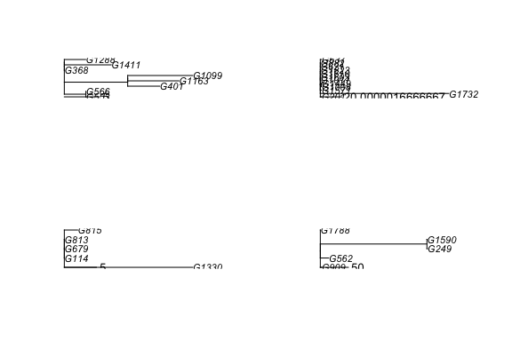

```r
# Alternatively, mltrees=lapply(aligns, function(x) estimate.tree(x, bf = basefreqs, maxit=10000,optQ=TRUE, optNni=TRUE))
par(mfrow=c(2,2)); lapply(mltrees,function(tree) {plot(tree); add.scale.bar()}); par(mfrow=c(1,1))
```

```r
# Improvement to do: coerce plots to increase height and width to show labels better
```

```r
mltrees[[1]]
```

```
#>
#> Phylogenetic tree with 8 tips and 6 internal nodes.
#>
#> Tip labels:
#>  G1099, G1163, G1288, G1411, G368, G401, ...
#>
#> Unrooted; includes branch lengths.
```

> 2b: Using sample dates, create timed trees using *treedater*.

```r
allDates <- read.csv(system.file("extdata", "valencia_dates.csv", package = "transnp", mustWork = TRUE))
sampledates <- setUpDates(aligns, allDates)
timedtrees <- createTimedTrees(mltrees, sampledates, aligns, strictClock = T, meanRateLimits = c(0.3, 0.7))
```

```
#> Note: Minimum temporal branch length  (*minblen*) set to 0.0187250000000006. Increase *minblen* in the event of convergence failures.
#> Tree is not rooted. Searching for best root position. Increase searchRoot to try harder.
#> Note: *dater* called with non binary tree. Will proceed after resolving polytomies.
#> Note: Minimum temporal branch length  (*minblen*) set to 0.0199916666666657. Increase *minblen* in the event of convergence failures.
#> Tree is not rooted. Searching for best root position. Increase searchRoot to try harder.
#> Note: *dater* called with non binary tree. Will proceed after resolving polytomies.
#> Note: Minimum temporal branch length  (*minblen*) set to 0.0309400000000005. Increase *minblen* in the event of convergence failures.
#> Tree is not rooted. Searching for best root position. Increase searchRoot to try harder.
#> Note: Minimum temporal branch length  (*minblen*) set to 0.0749200000000019. Increase *minblen* in the event of convergence failures.
#> Tree is not rooted. Searching for best root position. Increase searchRoot to try harder.
```

> Note: results depend on the clock assumptions and can affect onward analysis (long time vs short time). We are working towards incorporating this uncertainty.

## Step 3: transmission modelling

> Infer transmission trees using *TransPhylo* functionality This jointly estimates parameters over the trees, sharing parameters among the clusters We analyse different clusters together

```r
nIter <- 1000
tpTimedTrees <- list()
# Convert trees from phylo to TransPhylo format
#for (i in seq(length(timedtrees))){
#  tpTimedTrees[[i]] <- ptreeFromPhylo(timedtrees[[i]], max(sampledates[[i]]))
#}
maxDate <- max(unlist(lapply(sampledates, function(dateList) {return(max(dateList))})))
tpTimedTrees <- lapply(timedtrees, function(tree) {return(ptreeFromPhylo(tree, maxDate))})

record <- infer_multiTTree_shareParam(tpTimedTrees, share=c("neg","off.r","off.p","pi"), mcmcIterations=nIter, startNeg=1, startOff.p = 0.8, startOff.r = 1, startPi=0.9, updateNeg = T, updatePi = F, updateOff.p=FALSE)
```

> The result is a list of records, one for each cluster. The `record` object contains the inferred transmission trees.

## Step 4: Explore the results

### Transmission trees

> *Combined tree using TransPhylo*. In this tree, each colour corresponds to a host. Colours that don’t end up at a tip represent inferred unsampled cases. Note that this Bayesian analysis produces a collection of possible transmission trees. Here we show the one with highest posterior probability, for cluster 4.

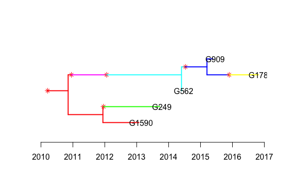

```r
maptree <- selectTTree(record[[4]],burnin = 0.3)
plotCTree(record[[4]][[maptree]]$ctree)
```

```r
library(visNetwork)
networkTPlot(record[[4]], mcmcIndex=nIter-10, missLabel="Missed", colours=c('lightblue', 'orange'))
```

[interactive chart not shown]

> Here is a different plot, for Cluster 2, showing different colour options.

```r
networkTPlot(record[[2]], mcmcIndex=nIter, missLabel="Missed", colours=c('blue', 'orange'))
```

[interactive chart not shown]

### How do the clusters compare to each other?

> We can plot distribution of generation times (one infection to the next) from the posterior.

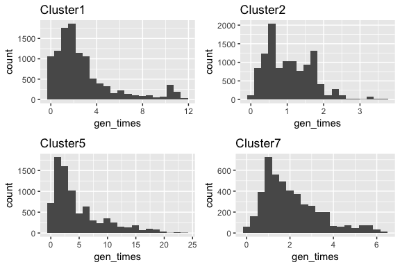

```r
names(record) = c("Cluster1", "Cluster2", "Cluster5", "Cluster7")
plot_gen_times(record)
```

> Clusters 1 and 5 contain some long times, suggesting cases that could have been intermittently infectious or non-infectious for a longer period. Cluster 2 seems to be moving faster.

> Times from getting infected to getting sampled, showing differences between clusters

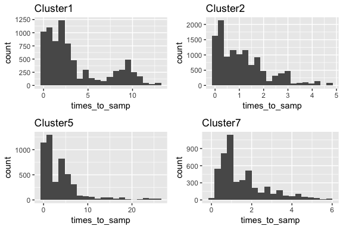

```r
plot_times_to_samp(record)
```

> The same pattern is mirrored in the times to sampling

> How many unsampled cases are estimated in the clusters?

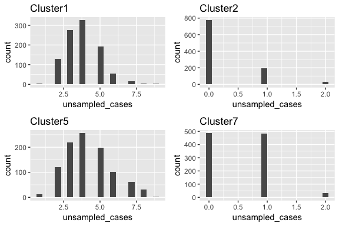

```r
plot_unsampled_cases(record)
```

### Individual-level estimes and uncertainty

> We can also extract individual-level infection times by case, for each cluster:

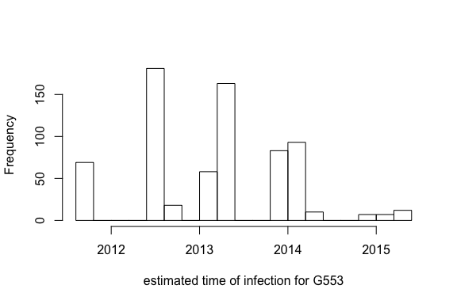

```r
gt11=getInfectionTimes(record[[1]][300:1000],7)
name1=record[[1]][[1000]]$ctree$nam[7]
hist(gt11,breaks=15,xlab = paste("estimated time of infection for", name1),main = "")
```

> The timing of infection depends on who infected whom and on the timed tree.

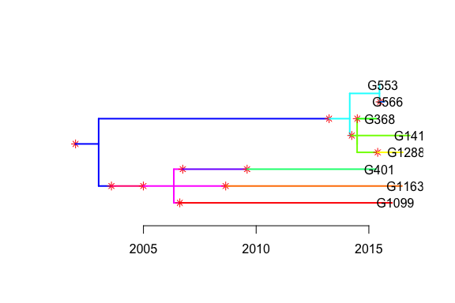

```r
maptree1=selectTTree(record[[1]],burnin = 0.5)
plotCTree(record[[1]][[maptree1]]$ctree)
```

## Acknowledgements

> Centre for Mathematics of Precision Healthcare, Imperial College London

> EPSRC Impact Acceleration award, Imperial College London

> Inaki Comas and Tom Irving: TB cluster data from Valencia, Spain

## Notes

transnp is work-in-progress[^1].

[^1]: On github soon!